# MEDS 2024 Applicant Statistics

This script analyzes the diversity of our applicant pool and creates a dataset, `diversity_contributions.csv`.

# Read in data

- `read_excel()` reads in the raw datasheet that Student Affairs downloads from the graduate portal
- `clean_names()` from the `janitor` package to make the column names nice and readable
- `mutate()` creates a new column, `application_id_name`. The values in this column are a combination of the values from `application_id`, `first_name` and `last_name`. These are combined using the `paste0()` function.

```r
raw <-  read_excel(here("data/Application Export 231204.xlsx")) %>% #read in excel sheet
  clean_names() %>% #this turns the column names into clean, readable names
  filter(objective1 == "MDS") %>%
  mutate(application_id_name =
           paste0(last_name, ", ", first_name, ": ", application_id)) %>%
  mutate(dob = gsub(' UTC','',dob))
```

# Diversity dataset

We can obtain information from the application about an applicants gender identity, racial background, if they have military service, if they are first generation, and whether or not they are citizens of a developing country.

## Identify Under-represented minorities

```r
urms <- c("African American / Black", "American Indian / Alaska Native")
```

## Assess diversity contributions

Using the `raw` dataset we create 6 new columns based on a set of conditions. Each of these columns will have either a “Y” (yes) or “N” (no) based on whether they meet the conditions. The only exception is for `woman_nonbinary` where a “U” will be used if the applicant did not disclose their gender.

#### `woman_nonbinary`

“Y” if an applicant lists “F”  
“N” if applicant lists “M”  
“U” if applicant lists “U”

#### `international`

“Y” if `visa` is “F-1 Student”, “J-1 Student” or other unique entry indicating international status

#### `undocumented`

“Y” if `visa` is “undocumented status” or other unique entry indicating undocumented, otherwise “N”

#### `military`

“Y” if any of “Discharged Veteran”, “National Guard”, or “Active Duty” are in `military_service`, otherwise “N”

#### `first_gen`

“Y” if `first_generation` is “Y”, otherwise “N”

We then select these 5 diversity columns along with the `application_id_name` along with some additional columns for our summary statistics.

The `report_to_ipeds` column is based on the conditions listed on the [IPEDS website](https://nces.ed.gov/ipeds/report-your-data/race-ethnicity-collecting-data-for-reporting-purposes).

```r
diversity_df <- raw %>%
  rowwise() %>%
  mutate(woman_nonbinary = case_when(
    gender == "Female" ~ "Yes",
    gender == "Male" ~ "No",
    gender == "Unknown" ~ "Undisclosed"),
    urm = case_when(
      hispanic_latino == TRUE & citizenship_country == "United States" ~ "Yes", #US citizens that are hispanic/latino
      hispanic_latino == TRUE & visa == "Permanent Resident" ~ "Yes", #permanent residents that are hispanic/latino
      TRUE %in% str_detect(racial_categories, urms) == TRUE & citizenship_country == "US" ~ "Yes", #US citizens that identify as an URM
      TRUE %in% str_detect(racial_categories, urms) == TRUE & visa == "Permanent Resident" ~ "Yes", #Permanent residents that identify as an URM
      TRUE ~ "No"
    ),
    international = ifelse(visa %in% c("F-1 Student", "F-2 Student Spouse", "J-1"), "Yes", "No"),
    english_language_skills = case_when(
      toefl_total_score < 95  ~ "Poor",
      ielts_overall < 7 ~ "Poor",
      toefl_total_score >= 95 & toefl_total_score < 100 ~ "Good",
      ielts_overall >=7 & ielts_overall <=7.5 ~ "Good",
      toefl_total_score >99 ~ "Strong",
      ielts_overall >=8 ~ "Strong",
      TRUE ~ ""),
    undocumented = case_when(
      visa == "undocumented status" ~ "Yes",
      is.na(visa) ~ "No",
      TRUE ~ "No"),
    military = ifelse(military_service %in% c("Discharged Veteran", "National Guard", "Active Duty"), "Yes", "No"),
    first_gen = ifelse(first_generation == "Yes", "Yes", "No"),
    report_to_ipeds = case_when(
      hispanic_latino == TRUE & international == "No" ~ "Hispanic",
      hispanic_latino == FALSE & !str_detect(racial_categories, ",") & international == "No" ~ racial_categories,
      hispanic_latino == FALSE & str_detect(racial_categories, ",") & international == "No" ~ "Two or more races",
      international == "Yes" ~ "Nonresident alien",
      is.na(hispanic_latino) & is.na(racial_categories) ~ "Unknown race and ethnicity",
      hispanic_latino == FALSE & is.na(racial_categories) ~ "Unknown race and ethnicity",
      is.na(hispanic_latino) & !is.na(racial_categories) & !str_detect(racial_categories, ",") ~ racial_categories,
      is.na(hispanic_latino) & !is.na(racial_categories) & str_detect(racial_categories, ",") ~ "Two or more races"
    )) %>%
  select(application_id_name, woman_nonbinary, urm, first_gen, international, undocumented, military, report_to_ipeds, english_language_skills)
```

# Save diversity dataset

These 6 columns will be included in the google sheet we share with faculty reviewers. We want to save the applicant_id_name and the 5 diversity categories.

```r
diversity_df %>%
  write_csv(here("data/diversity_contributions.csv"))
```

## Summary statistics:

17% are under-represented minorities  
62% are women  
21% are international  
16% are first generation  
6% identify as multiracial  
0% are undocumented

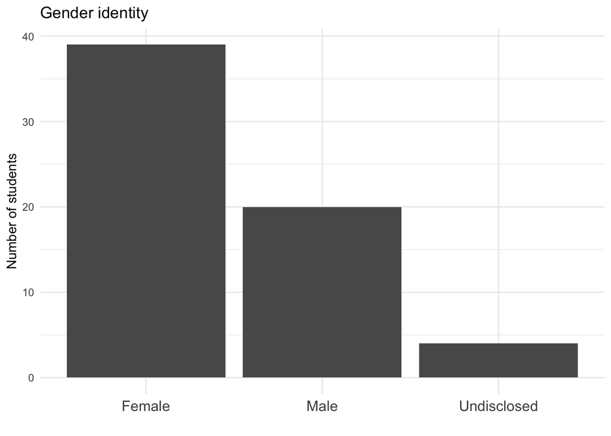

```r
labels <- c("Female", "Male", "Undisclosed")

ggplot(raw, aes(x = gender)) +
  geom_bar() +
  theme_minimal() +
  labs(y = "Number of students",
       x = "",
       title = "Gender identity") +
  scale_x_discrete(labels= labels) +
  theme(axis.text.x = element_text(size=12))
```

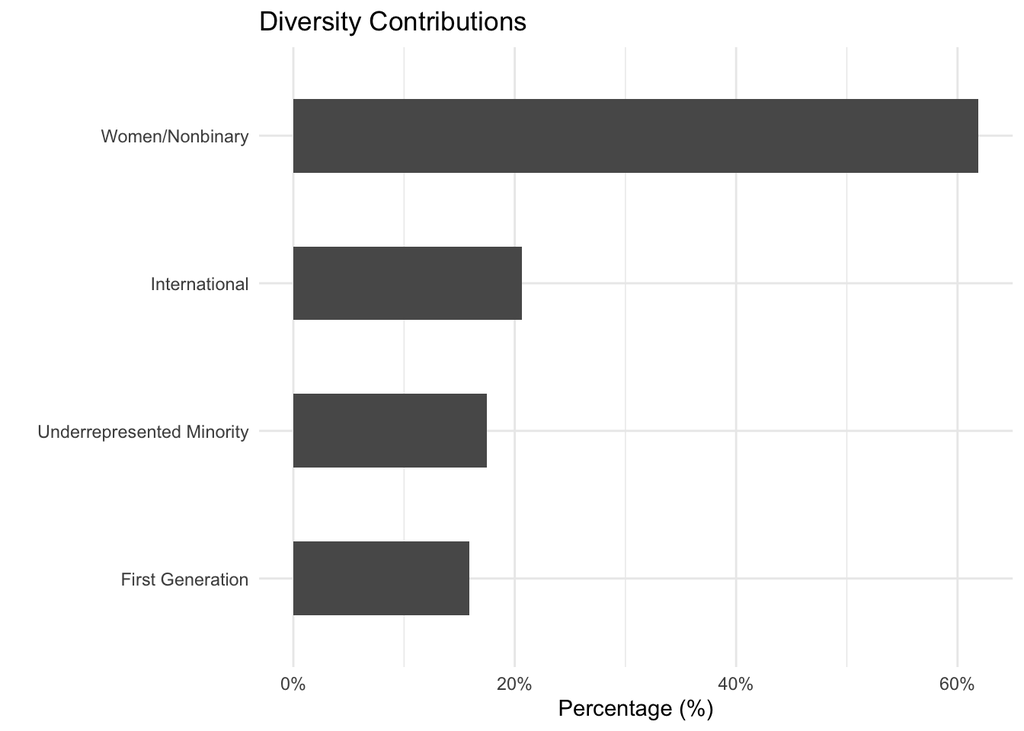

```r
div_df_ggplot <- diversity_df %>%
  pivot_longer(cols = 2:9) %>%
  rename(diversity_category = name) %>%
  filter(!diversity_category %in% c("report_to_ipeds", "english_language_skills")) %>%
  filter(value == "Yes") %>%
  group_by(diversity_category) %>%
  summarize(percentage = n()/nrow(diversity_df))

labs <- c("First Generation", "Underrepresented Minority", "International", "Women/Nonbinary" )
ggplot(div_df_ggplot, aes(x = reorder(diversity_category, percentage), y = percentage,  xlab="")) +
  geom_bar(stat="identity", width=.5, position = "dodge") +
  theme_minimal() +
  labs(x = "", y = "Percentage (%)", fill = "", title = "Diversity Contributions") +
  coord_flip() +
  scale_y_continuous(labels=scales::percent_format()) +
  scale_x_discrete(labels= labs)
```

# Age

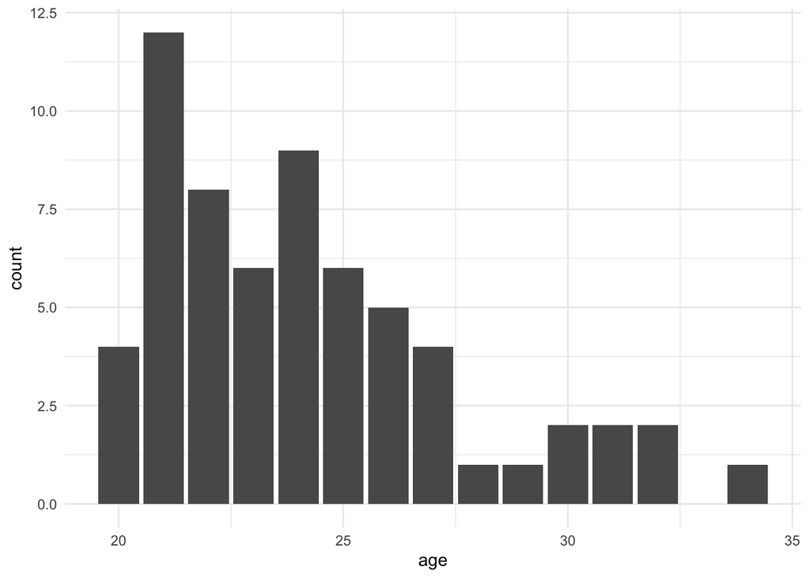

```r
age <- raw %>%
  select(application_id_name, dob) %>%
  mutate(age = trunc(as.numeric(difftime(Sys.Date(), dob, units = "days")) / 365.25))

ggplot(age, aes(x = age)) +
  geom_bar() +
  theme_minimal()
```

The median age is 24 with a range of 20 to 34

# IPEDS Categories

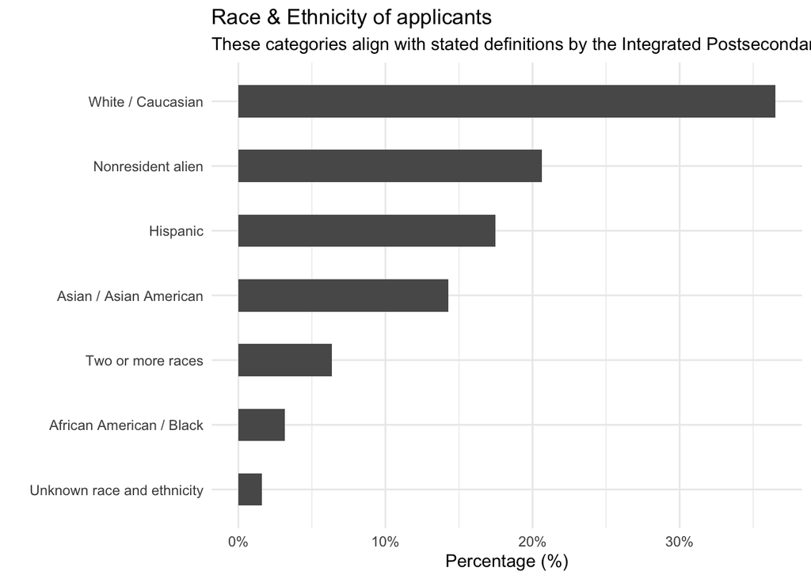

```r
ipeds <- diversity_df %>%
  group_by(report_to_ipeds) %>%
  summarize(percentage = n()/nrow(raw))


#plot

ggplot(ipeds, aes(x = reorder(report_to_ipeds, percentage), y = percentage,  xlab="")) +
  geom_bar(stat="identity", width=.5, position = "dodge") +
  theme_minimal() +
  labs(x = "", y = "Percentage (%)", fill = "", title = "Race & Ethnicity of applicants", subtitle = "These categories align with stated definitions by the Integrated Postsecondary Education Data System (IPEDS)") +
  coord_flip() +
  scale_y_continuous(labels=scales::percent_format())
```

# Undergraduate degrees

This wordcloud shows all of the different undergraduate majors listed by our applicants. The size of the words increases with the number of occurrences.

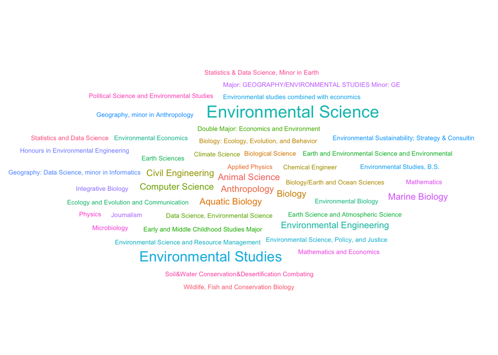

```r
degrees <- raw %>%
  group_by(ug1_major) %>%
  summarize(count = n())

ggplot(degrees, aes(label = ug1_major, size = count, color = ug1_major)) +
  geom_text_wordcloud() +
  scale_size_area(max_size = 6) +
  theme_minimal()
```

## Where are our students coming from?

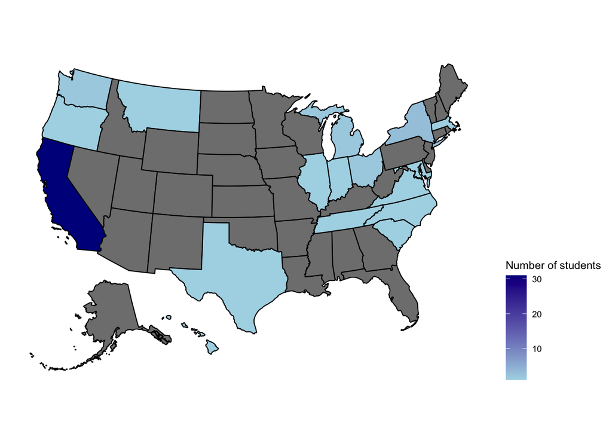

```r
#united states locations
us_ug_locations <- raw %>%
  select(ug1_location) %>%
  filter(str_detect(ug1_location, "US - ")) %>%
  separate(ug1_location, into = c("country", "state"), sep = " - ") %>%
  group_by(state) %>%
  summarize(count = n())

plot_usmap(data = us_ug_locations, values = "count") +
  scale_fill_continuous(
    low = "lightblue", high = "darkblue", name = "Number of students", label = scales::comma
  ) + theme(legend.position = "right")
```

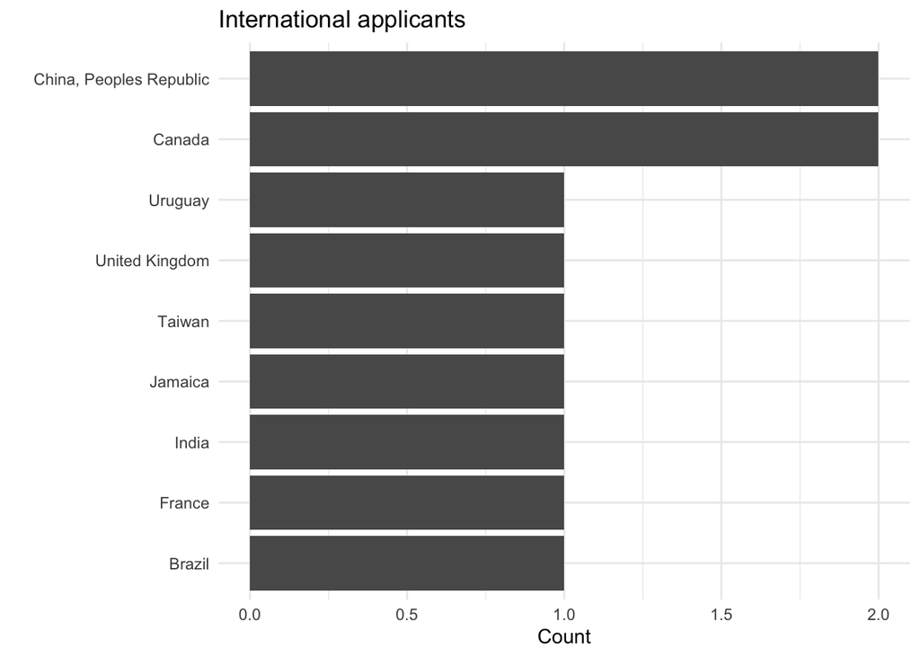

```r
#international locations
int_ug_locations <- raw %>%
  select(ug1_location) %>%
  filter(!str_detect(ug1_location, "US - ")) %>%
  group_by(ug1_location) %>%
  summarize(count = n())

ggplot(int_ug_locations, aes(x = reorder(ug1_location, count), y = count,  xlab="")) +
  geom_bar(stat="identity",  position = "dodge") +
  theme_minimal() +
  labs(x = "", y = "Count", fill = "", title = "International applicants") +
  coord_flip()
```

```r
#college scorecard data loaded just to grab lat long
cs <- read_csv(here("data/Most-Recent-Cohorts-Institution.csv") )
ug_institutions <- raw %>%
  group_by(ug1_name) %>%
  summarize(count = n()) %>%
  ungroup() %>%
  mutate(school_name = case_when(
    ug1_name == "Foothill College" ~ "Foothill College",
    ug1_name == "CAL POLY HUMBOLDT" ~ "Humboldt State University",
    ug1_name == "UC LOS ANGELES (UCLA)" ~ "University of California-Los Angeles",
    ug1_name == "UNIV OF VIRGINIA UNDERGRADUATE" ~ "University of Virginia-Main Campus",
    ug1_name == "EL CAMINO COLLEGE" ~ "El Camino Community College District",
    ug1_name == "UNIV TEXAS AUSTIN" ~ "The University of Texas at Austin",
    ug1_name == "UNIV MICHIGAN ANN ARBOR" ~ "University of Michigan-Ann Arbor",
    ug1_name == "STONY BROOK UNIVERSITY SUNY" ~ "Stony Brook University",
    ug1_name == "OHIO STATE UNIV COLUMBUS" ~ "Ohio State University-Main Campus",
    ug1_name == "UNIV ILLINOIS URBANA" ~ "University of Illinois Urbana-Champaign",
    ug1_name == "Cal Poly Pomona" ~ "California State Polytechnic University-Pomona",
    ug1_name == "UC SAN DIEGO" ~ "University of California-San Diego",
    ug1_name == "UC IRVINE" ~ "University of California-Irvine",
    ug1_name == "AMERICAN UNIVERSITY OF PARIS" ~ "American University of Paris",
    ug1_name == "SANTA CLARA UNIVERSITY" ~ "Santa Clara University",
    ug1_name == "UNIV ARKANSAS FAYETTEVILLE" ~ "University of Arkansas",
    ug1_name == "SKYLINE COLLEGE" ~ "Skyline College",
    ug1_name == "OREGON STATE UNIVERSITY" ~ "Oregon State University",
    ug1_name == "TOWSON UNIVERSITY" ~ "Towson University",
    ug1_name == "IOWA STATE UNIVERSITY" ~ "Iowa State University",
    ug1_name == "UNIV COLORADO BOULDER" ~ "University of Colorado Boulder",
    ug1_name == "CARLETON COLLEGE" ~ "Carleton College",
    ug1_name == "UNIV FEDERAL DE SANTA MARIA" ~ "Universidad Federal de Santa Maria",
    ug1_name == "UNIV IBEROAMERICANA" ~ "Universidad Iberoamericana",
    ug1_name == "COLLEGE OF THE CANYONS" ~ "College of the Canyons",
    ug1_name == "DAVIDSON COLLEGE" ~ "Davidson College",
    ug1_name == "COLORADO COLLEGE" ~ "Colorado College",
    ug1_name == "UNIVERSITY OF PUGET SOUND" ~ "University of Puget Sound",
    ug1_name == "UNIV DELAWARE" ~ "University of Delaware",
    ug1_name == "UNIV NORTH CAROLINA ASHEVILLE" ~ "University of North Carolina at Asheville",
    ug1_name == "SANTA MONICA COLLEGE" ~ "Santa Monica College",
    ug1_name == "OCCIDENTAL COLLEGE" ~ "Occidental College",
    ug1_name == "CHAMINADE UNIV OF HONOLULU" ~ "Chaminade University of Honolulu",
    ug1_name == "UNIV HAWAII MANOA" ~ "University of Hawaii at Manoa",
    ug1_name == "UNIV MASS STCKBR SCH" ~ "University of Massachusetts-Amherst",
    ug1_name == "UC SANTA BARBARA" ~ "University of California-Santa Barbara",
    ug1_name == "UC SANTA BARBARA EXTENDED" ~ "University of California-Santa Barbara",
    ug1_name == "UC DAVIS" ~ "University of California-Davis",
    ug1_name == "UC BERKELEY" ~ "University of California-Berkeley",
    ug1_name == "UC RIVERSIDE" ~ "University of California-Riverside",
    ug1_name == "HUMBOLDT STATE UNIVERSITY" ~ "Humboldt State University",
    ug1_name == "HARVARD UNDERGRAD ADMISSIONS" ~ "Harvard University",
    ug1_name == "MCGILL UNIVERSITY" ~ "McGill University",
    ug1_name == "NORTHEASTERN UNIVERSITY" ~ "Northeastern University",
    ug1_name == "TUFTS UNIVERSITY" ~ "Tufts University",
    ug1_name == "UC SANTA CRUZ" ~ "University of California-Santa Cruz",
    ug1_name == "REED COLLEGE" ~ "Reed College",
    ug1_name == "CAL POLY SAN LUIS OBISPO" ~ "California Polytechnic State University-San Luis Obispo",
    ug1_name == "UNIVERSITY OF WASHINGTON" ~ "University of Washington-Seattle Campus",
    ug1_name == "UNIVERSITY WISCONSIN PARKSIDE" ~ "University of Wisconsin-Parkside",
    ug1_name == "BOSTON UNIVERSITY" ~ "Boston University",
    ug1_name == "UNIVERSITY OF VERMONT" ~ "University of Vermont",
    ug1_name == "UNIV SOUTHERN CALIFORNIA" ~ "University of Southern California",
    ug1_name == "UNIV OF MARYLAND" ~ "University of Maryland-College Park",
    ug1_name == "TEMPLE UNIVERSITY" ~ "Temple University",
    ug1_name == "BOWDOIN COLLEGE" ~ "Bowdoin College",
    ug1_name == "COLORADO SCHOOL MINES" ~ "Colorado School of Mines",
    ug1_name == "CHABOT COLLEGE" ~ "Chabot College",
    ug1_name == "ST MARYS COLLEGE OF MARYLAND" ~ "St. Mary's College of Maryland",
    ug1_name == "BROWN UNIVERSITY" ~ "Brown University",
    ug1_name == "CUNY THE CITY COLLEGE OF NY" ~ "CUNY City College",
    ug1_name == "California State University, Monterey Bay" ~ "California State University-Monterey Bay",
    ug1_name == "MONTANA STATE UNIV BOZEMAN" ~ "Montana State University",
    ug1_name == "MIAMI UNIVERSITY" ~ "Miami University-Oxford",
    ug1_name == "UNIV COLLEGE NORTHAMPTON" ~ "University of Northampton",
    ug1_name == "SIMON FRASER UNIVERSITY" ~ "Simon Fraser University",
    ug1_name == "State University of Information-Communication Tech" ~ "State University of Information and Communication Technology"
    )) %>%
  left_join(cs, by = c("school_name" = "INSTNM")) #%>%
  # mutate(LATITUDE = case_when(
  #   school_name == "University of Northampton" ~ 52.231433632034566,
  #   school_name == "Simon Fraser University" ~ 49.2782544790141,
  #   school_name == "State University of Information and Communication Technology" ~ 50.45464416192778,
  #   TRUE ~ as.numeric(LATITUDE)),
  #   LONGITUDE = case_when(
  #   school_name == "University of Northampton" ~ -0.8868492674312192,
  #   school_name == "Simon Fraser University" ~ -122.9198296400421,
  #   school_name == "State University of Information and Communication Technology" ~ 30.377297779838678,
  #   TRUE ~ as.numeric(LONGITUDE))
  # )
```

```r
#turn data into sf object
df_sf = st_as_sf(ug_institutions %>% filter(!is.na(school_name)), coords = c("LONGITUDE", "LATITUDE"),
                 crs = 4326, agr = "constant") %>%
  select(-CITY, -STABBR, -ug1_name)

mapview::mapview(df_sf, legend = FALSE, cex = "count",
                 zcol = "school_name", popup = popupTable(df_sf, zcol = "count"))
```

[interactive chart not shown]